# Assignment 1: Basic Programming in R

Kohei Kawaguchi

2019/2/11

Report the following results in html format using R markdown. In other words, replicate this document. You write functions in a separate R file and put in `R` folder in the project folder. Build the project as a package and load it from the R markdown file. The execution code sholuld be written in R markdown file.

You submit:

- R file containing functions.
- R markdown file containing your answers and executing codes.
- HTML(or PDF) report generated from the R markdown.

## Simulate data

Consider to simulate data from the following model and estimate the parameters from the simulated data.

$$y_{ij} = 1\{j = \text{argmax}_{k = 1, 2} \beta x_k + \epsilon_{ik} \},$$
where $\epsilon_{ik}$ follows i.i.d. type-I extreme value distribution, $\beta = 0.2$, $x_1 = 0$ and $x_2 = 1$.

1. To simulate data, first make a data frame as follows:

```r
df
```

```
## # A tibble: 2,000 × 3
##        i     k     x
##    <int> <int> <dbl>
##  1     1     1     0
##  2     1     2     1
##  3     2     1     0
##  4     2     2     1
##  5     3     1     0
##  6     3     2     1
##  7     4     1     0
##  8     4     2     1
##  9     5     1     0
## 10     5     2     1
## # ℹ 1,990 more rows
```

2. Second, draw type-I extreme value random variables. Set the seed at 1. You can use `evd` package to draw the variables. You should get exactly the same realization if the seed is correctly set.

```r
set.seed(1)
```

```r
df
```

```
## # A tibble: 2,000 × 4
##        i     k     x       e
##    <int> <int> <dbl>   <dbl>
##  1     1     1     0  0.281
##  2     1     2     1 -0.167
##  3     2     1     0  1.93
##  4     2     2     1  1.97
##  5     3     1     0  0.830
##  6     3     2     1 -1.06
##  7     4     1     0 -0.207
##  8     4     2     1  0.617
##  9     5     1     0  0.0444
## 10     5     2     1  1.92
## # ℹ 1,990 more rows
```

3. Third, compute the latent value of each option to obtain the following data frame:

```r
beta <- 0.2
```

```r
df
```

```
## # A tibble: 2,000 × 5
##        i     k     x       e  latent
##    <int> <int> <dbl>   <dbl>   <dbl>
##  1     1     1     0  0.281   0.281
##  2     1     2     1 -0.167   0.0331
##  3     2     1     0  1.93    1.93
##  4     2     2     1  1.97    2.17
##  5     3     1     0  0.830   0.830
##  6     3     2     1 -1.06   -0.863
##  7     4     1     0 -0.207  -0.207
##  8     4     2     1  0.617   0.817
##  9     5     1     0  0.0444  0.0444
## 10     5     2     1  1.92    2.12
## # ℹ 1,990 more rows
```

4. Finally, compute $y$ by comparing the latent values of $k = 1, 2$ for each $i$ to obtain the following result:

```r
df
```

```
## # A tibble: 2,000 × 6
##        i     k     x       e  latent     y
##    <int> <int> <dbl>   <dbl>   <dbl> <dbl>
##  1     1     1     0  0.281   0.281      1
##  2     1     2     1 -0.167   0.0331     0
##  3     2     1     0  1.93    1.93       0
##  4     2     2     1  1.97    2.17       1
##  5     3     1     0  0.830   0.830      1
##  6     3     2     1 -1.06   -0.863      0
##  7     4     1     0 -0.207  -0.207      0
##  8     4     2     1  0.617   0.817      1
##  9     5     1     0  0.0444  0.0444     0
## 10     5     2     1  1.92    2.12       1
## # ℹ 1,990 more rows
```

## Estimate the parameter

Now you generated simulated data. Suppose you observe $x_k$ and $y_{ik}$ for each $i$ and $k$ and estimate $\beta$ by a maximum likelihood estimator. The likelihood for $i$ to choose $k$ ($y_{ik} = 1$) can be shown to be:
$$p_{ik}(\beta) = \frac{\exp(\beta x_k)}{\exp(\beta x_1) + \exp(\beta
x_2)}.$$

Then, the likelihood of observing $\{y_{ik}\}_{i, k}$ is:
$$L(\beta) = \prod_{i = 1}^{1000} p_{i1}(\beta)^{y_{i1}} [1 -
p_{i1}(\beta)]^{1 - y_{i1}},$$
and the log likelihood is:
$$l(\beta) = \sum_{i = 1}^{1000}\{y_{i1}\log p_{i1}(\beta) + (1 -
y_{i1})\log [1 - p_{i1}(\beta)\}.$$

1. Write a function to compute the likelihood for a given $\beta$ and data and name the function `compute_loglikelihood_a1(b, df)`.

```r
compute_loglikelihood_a1(
    b = 1,
    df = df
  )
```

```
## [1] -0.7542617
```

1. Compute the value of log likelihood for $\beta = 0, 0.1, \cdots, 1$ and plot the result using `ggplot2` packages. You can use `latex2exp` package to use LaTeX math symbol in the label:

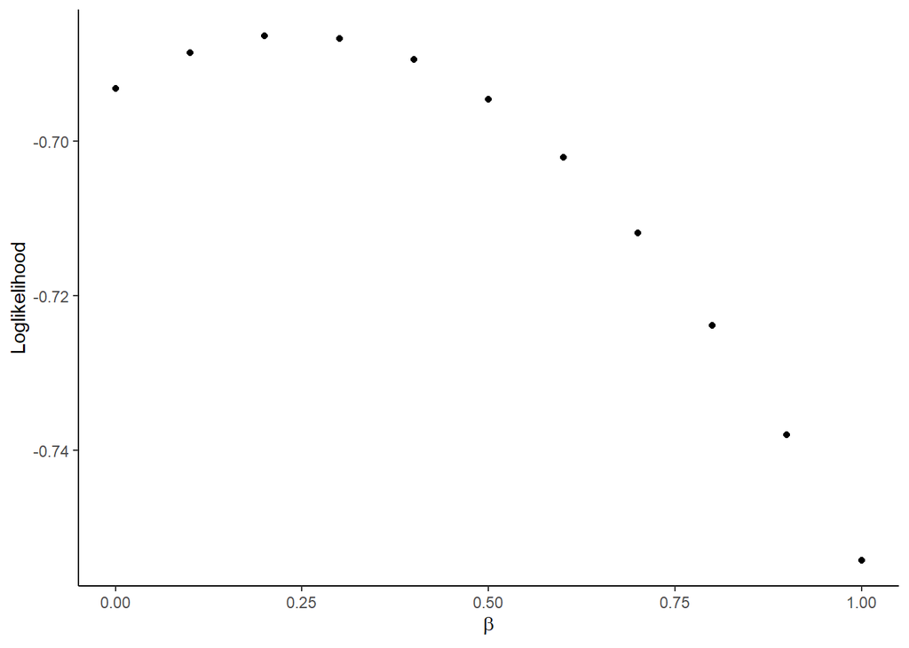

```r
b_seq <- seq(0, 1, 0.1)
output <-
  foreach (
    b = b_seq,
    .combine = "rbind"
    ) %do% {
      l <-
        compute_loglikelihood_a1(
          b,
          df
          )
      return(l)
}
output <-
  data.frame(
    x = b_seq,
    y = output
    )
output %>%
  ggplot(
    aes(
      x = x,
      y = y
      )
    ) +
  geom_point() +
  xlab(TeX("$\\beta$")) +
  ylab("Loglikelihood") +
  theme_classic()
```

1. Find and report $\beta$ that maximizes the log likelihood for the simulated data. You can use `optim` function to achieve this. You will use `Brent` method and set the lower bound at -1 and upper bound at 1 for the parameter search.

```
## $par
## [1] 0.2371046
##
## $value
## [1] -0.6861689
##
## $counts
## function gradient
##       NA       NA
##
## $convergence
## [1] 0
##
## $message
## NULL
```